# BIOL 607 Homework 3

### 3b. Make a boxplot showing the variability in sea ice extent every month.

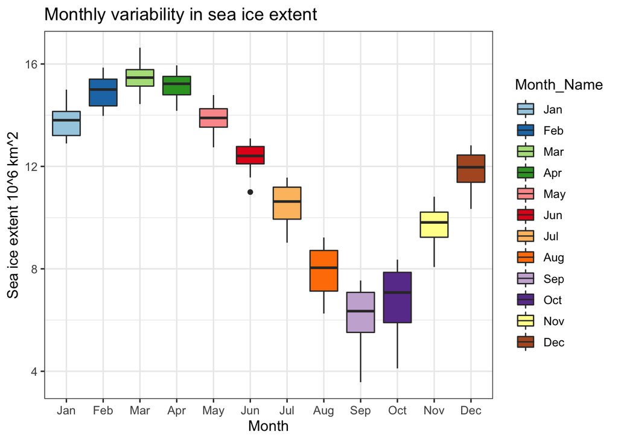

```r
month_extent <- ggplot(data=ice, mapping=aes(x=Month_Name, y=Extent, fill=Month_Name))+
  geom_boxplot()+ #plot ice extent by discrete variable (Month_Name) and color by month
  labs(x="Month",
       y="Sea ice extent 10^6 km^2",
       title="Monthly variability in sea ice extent")+
  scale_fill_brewer(palette="Paired")

month_extent
```

### 3c. Use dplyr to get the annual minimum sea ice extent. Plot minimum ice by year. What do you observe?

I see that the annual minimum sea ice extent has decreased over time between 1978 and 2016.

```r
#use dplyr to get annual min ice extent:
min_extent <- ice %>%
  group_by(Year) %>% #group sea ice data by year
  summarize(min_extent=min(Extent)) #for each year, calculate minimum sea ice extent

str(min_extent) #check output
```

```
## tibble [39 × 2] (S3: tbl_df/tbl/data.frame)
##  $ Year      : num [1:39] 1978 1979 1980 1981 1982 ...
##  $ min_extent: num [1:39] 10.67 7.23 7.54 7.2 7.4 ...
```

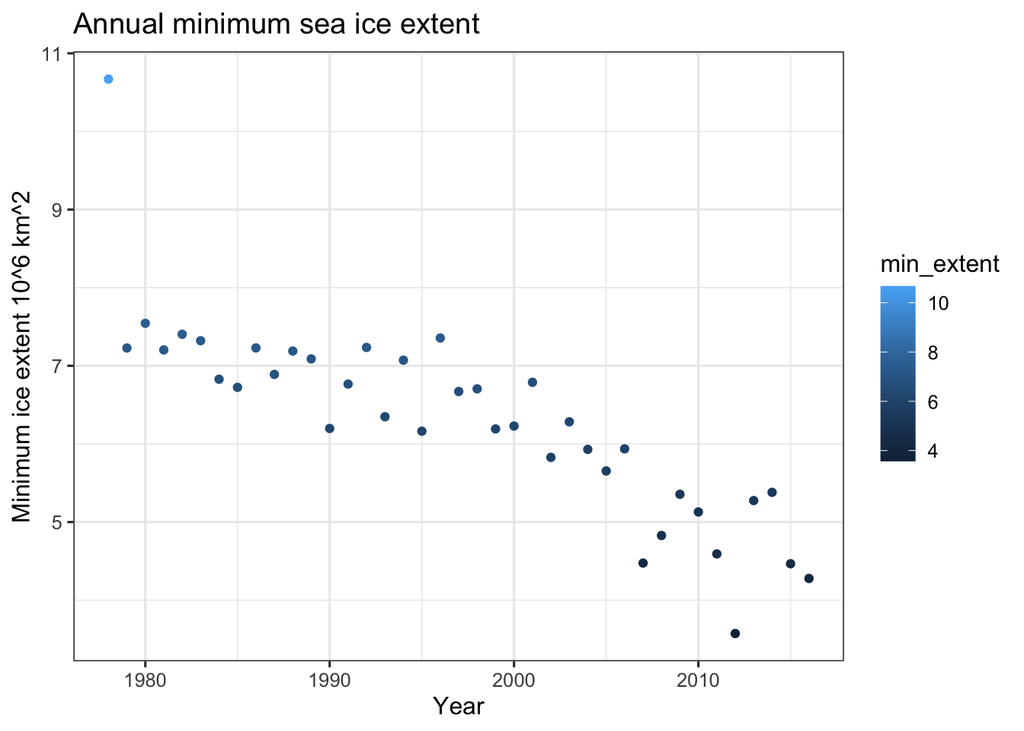

```r
#plot min ice by year:
min_extent %>%
  ggplot(aes(x=Year, y=min_extent, color=min_extent))+
  labs(x="Year",
       y="Minimum ice extent 10^6 km^2",
       title="Annual minimum sea ice extent")+
  geom_point() #make a scatter plot to see the trend over time
```

### 3d. One thing that’s really cool about faceting is that you can use cut_*() functions on continuos variables to make facets by groups of continuous variables. To see what I mean, try cut_interval(1:10, n = 5) See how it makes five bins of even width? We use cut_interval() or other cut functions with faceting like so facet_wrap(~cut_interval(some_variable)).

### With the original data, plot sea ice by year, with different lines (oh! What geom will you need for that?) for different months. Then, use facet_wrap and cut_interval(Month, n=4) to split the plot into seasons.

```r
cut_interval(1:10, n = 5) #testing cut interval
```

```
##  [1] [1,2.8]   [1,2.8]   (2.8,4.6] (2.8,4.6] (4.6,6.4] (4.6,6.4] (6.4,8.2]
##  [8] (6.4,8.2] (8.2,10]  (8.2,10]
## Levels: [1,2.8] (2.8,4.6] (4.6,6.4] (6.4,8.2] (8.2,10]
```

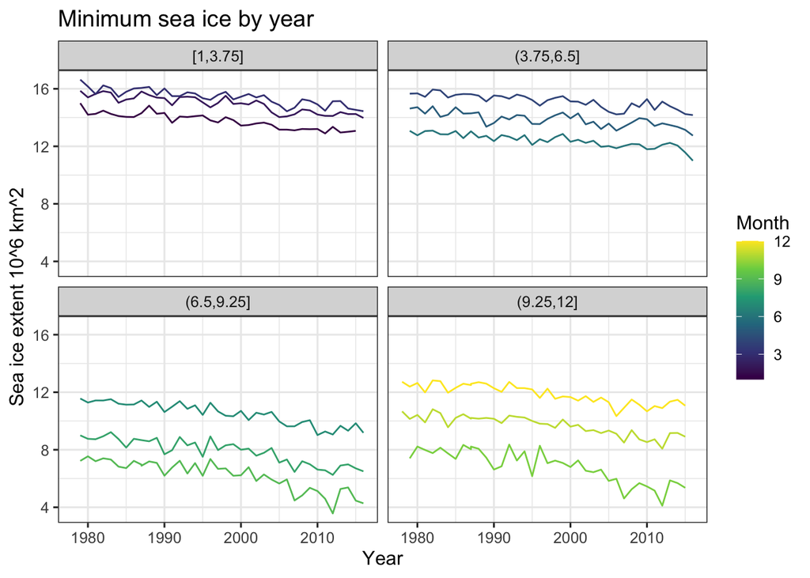

```r
ice %>%
  #plot extent by year, with a separate line for each month (group)
  ggplot(aes(x=Year, y=Extent, group= Month, color=Month))+
  labs(x="Year",
       y="Sea ice extent 10^6 km^2",
       title="Minimum sea ice by year")+
  #use geom_line to visualize trend over time
  geom_line()+
  scale_color_viridis_c(option = "D")+
  #facet wrap by season (3 month intervals)
  facet_wrap(~cut_interval(Month, n=4))
```

### 3e. Last, make a line plot of sea ice by month with different lines as different years. Gussy it up with colors by year, a different theme, critical values, and whatever other annotations, changes to axes, etc., you think best show the story of this data. For ideas, see the lab, and look at various palettes around. Extra credit for using colorfindr to make a palette.

```r
min(ice$Extent)#find min ice extent, =3.573 in 2012
```

```
## [1] 3.573
```

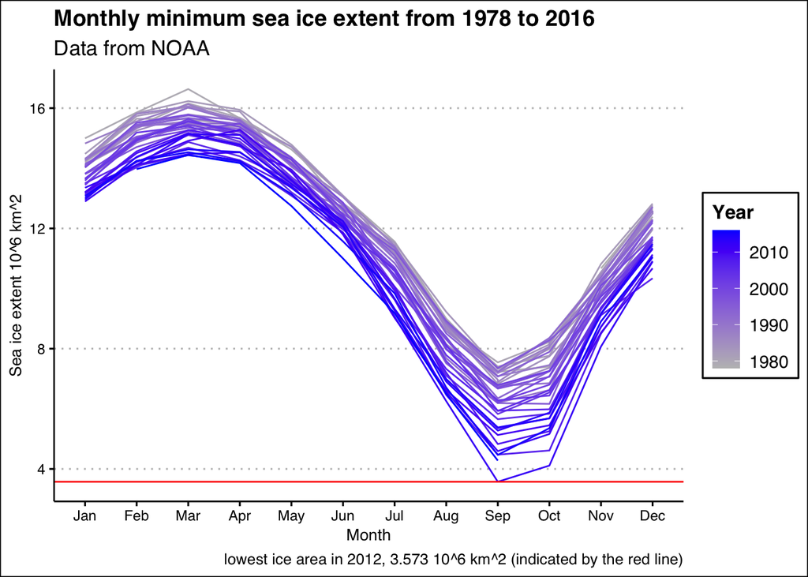

```r
#plot extent by month, with a separate line for each year (group)
ggice1 <-ggplot(data=ice, mapping=aes(x=Month_Name, y=Extent, group=Year, color=Year))+
  labs(x="Month",
       y="Sea ice extent 10^6 km^2",
       title="Monthly minimum sea ice extent from 1978 to 2016",
       subtitle = "Data from NOAA",
       caption= "lowest ice area in 2012, 3.573 10^6 km^2 (indicated by the red line)")+
  geom_line()+ #use geom_line to visualize trend over time
  geom_hline(yintercept= min(ice$Extent), color= "red")+ #add line to show lowest extent value
  scale_color_gradient(low="gray", high="blue")+ #color as a gradient of years
  theme_clean()

ggice1
```

### Extra credit: tried colorfindr

This plot is probably not as helpful as the one above because year is not color-coded as a continuous variable and it is hard to see which year is which. However, it does match the colors of the melting ice.

Inspiration from national geographic:

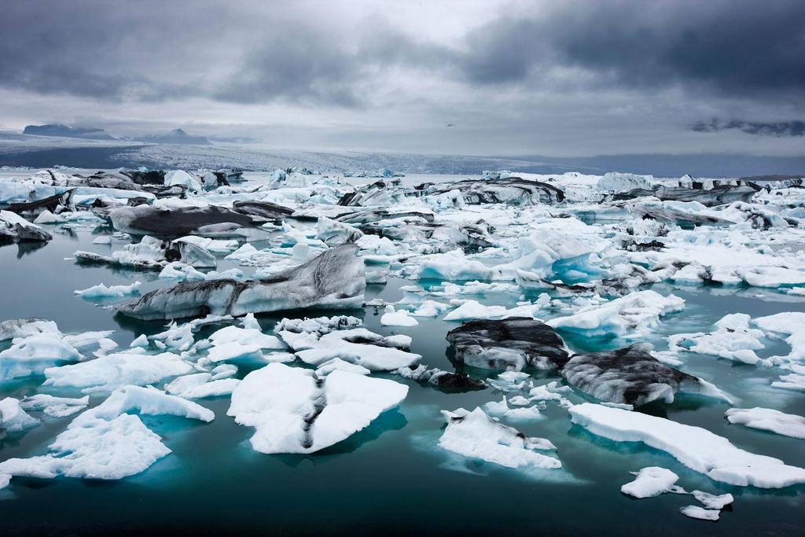

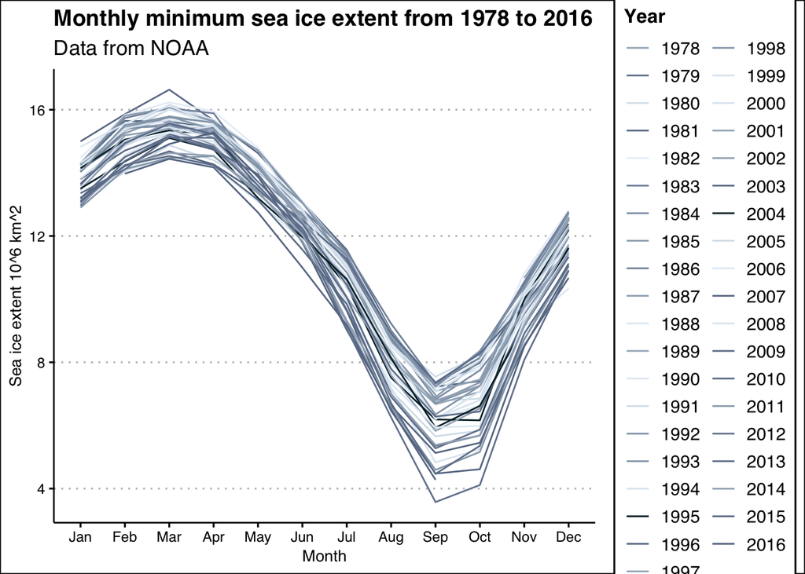

```r
#Extra credit: try colorfindr
library(colorfindr)

#Find top 100 colors from NatGeo melting ice picture
last_ice <- get_colors("https://www.nationalgeographic.com/content/dam/environment/2018/12/book_glaciers/01_book_glacier_h_12_7_00010056.ngsversion.1545405649508.adapt.1900.1.jpg",
                       top_n = 100, exclude_col ="white") #exclude white from list of colors
last_ice_pallette <- last_ice$col_hex #make an object from a vector of colors to serve as color values in plot

ice2 <- ice %>%
  mutate(year_factor=as.factor(Year)) #mutate year to factor so that palette can color it as discrete

#plot extent by month, with a separate line for each year (group)
ggice_colorfindr <-ggplot(data=ice2, mapping=aes(x=Month_Name, y=Extent, group=Year, color=year_factor))+ #using year as a factor for color
  labs(x="Month",
       y="Sea ice extent 10^6 km^2",
       title="Monthly minimum sea ice extent from 1978 to 2016",
      subtitle = "Data from NOAA",
       legend="Year")+
  geom_line()+
  labs(color="Year") + #relabel legend from "year_factor"
  scale_color_manual(values = last_ice_pallette[30:69])+ #color with NatGeo ice colors, selecting 39 values for the 39 years
  theme_clean()

ggice_colorfindr
```

### Extra credit: tried animation

```r
ggice_animate <-ggplot(data=ice2, mapping=aes(x=Month_Name, y=Extent, group=Year, color=Year))+
  labs(x="Month",
       y="Sea ice extent 10^6 km^2",
        subtitle = "Data from NOAA",
       title="Monthly minimum sea ice extent from 1978 to 2016")+
  geom_line()+
  scale_color_gradient(low="gray", high="blue")+
  theme_clean()+
  transition_reveal(Year) + #reveal years with each frame
  ease_aes("linear")

animate(ggice_animate)
```

[output not shown]

## *Extra credit:* submitted via GitHub.

### Repository: https://github.com/ninamcdonnell/biol607_mcdonnell/tree/master/homework/homework_markdown